# Rendu Projet Monte-Carlo

Guillaume et Jeremy Gr 209

28 novembre 2020

# Exo1

**1.** On souhaite simuler une variable aléatoire $(X,Y)$ de densié $f=a\psi$. Pour appliquer l’algorithme de trajet on majore $f$ par une densité telle que
$$\forall x \in R^2, f(x,y)\leq M_1*h(x,y)$$
avec $M_1$ une constant supérieur ou égale à 1. Cela revient à majorer $\psi$ par une fonction $g$ de sorte que
$$\forall x \in R^2, \psi(x,y)\leq M*g(x,y)$$
on aura alors $f(x,y)\leq a*M*g(x,y)$. On applique alors l’algorithme du rejet et on tire:
$(U_n)_{n>0} \overset{iid}\sim U([0,1])$ et $(X_n,Y_n)_{n>0}$ suite de variabes iid suivant la loi de densité $ag$ et tel que $\forall n>0, U_n$ indépendant du couple $(X_n,Y_n)$.
Pour simuler une variable selon la loi de densité f on pose le temps d’arret $T=inf\{n\geq1 : Un \leq \frac{f(X_n,Y_n)}{a*M*g(X_n,Y_n)}=\frac{\psi(X_n,Y_n)}{M*g(X_n,Y_n)} \}$. On voit que le $a$ n’est pas important pour tirer une observaton selon la loi de densité $f$:il suffit de majorer $\psi$ et simuler nos variables aléatoires selon $g$.

Dans notre cas :
$$\begin{align}
\psi(x,y) &= (|\sin(\frac{2}{\pi}x^2-\frac{\pi}{4})|+4\cos^2(x)+y^4)e^{-2(x+|y|)}1_{x \in [-\frac{\pi}{2};\frac{\pi}{2}]}1_{y \in [-1;1]}\\
&\leq (\frac{\sqrt2}{2}+5)e^{-2x}e^{-2|y|}1_{x \in [-\frac{\pi}{2};\frac{\pi}{2}]}1_{y \in [-1;1]}\\
&\leq (\frac{\sqrt2}{2}+5)(\frac{1}{2}e^{2\frac{\pi}{2}}*2e^{-2(x+\frac{\pi}{2})}1_{x \in [-\frac{\pi}{2};\frac{\pi}{2}]})(e^{2y^2}\frac{\sqrt{2\pi*0.25}}{\sqrt{2\pi*0.25}}1_{y \in [-1;1]}) && \text{preuve de la majoration plus bas }\\
&\leq (\frac{\sqrt2}{2}+5)\frac{1}{2}e^{\pi}\sqrt{\frac{\pi}{2}}* l(x)*h(y)=(\frac{\sqrt2}{2}+5)\frac{1}{2}e^{\pi}\sqrt{\frac{\pi}{2}}*g(x,y)\\ &\text{avec l la densité de la loi exponentielle translatée (-pi/2) et tronquée et h la densité de la loi normale N(0,0.25) tronquée}
\end{align}$$
Explication de la majoration de $e^{-2|y|}1_{y \in [-1;1]}$ : (passage de la ligne 2 à la ligne 3)

$$\begin{align}
\forall y \in [-1,1],|y|&\geq y^2\\
-|y|&\leq -y^2\\
e^{-2|y|}&\leq e^{-2y^2} = \sqrt{2\pi*0.25}*f_{N(0,0.25)}(x)
\end{align}$$
**2.**

```r
gen_normal <- function(n)
{
  U <- runif(n %/% 2)
  V <- runif(n %/% 2)

  Y <- runif(n %% 2)
  Z <- runif(n %% 2)
  D <-
    sqrt(-2 * log(Y)) * cos(2 * pi * Z) #Si n est impair l'observation manquante est réalisé par ce calcul

  W <- sqrt(-2 * log(U)) * cos(2 * pi * V)
  X <- sqrt(-2 * log(U)) * sin(2 * pi * V)
  Z <- 0.5 * c(W, X, D)  #On multiplie pour avoir une N(0,0.25)
  P <- Z[Z > (-1) & Z < (1)]
  N <- Z[Z < (-1) | Z > (1)]
  while (length(N) != 0) #Tant qu'il reste des valeurs au dessus de 1 ou en dessousde -1 on retire  des uniformes
  {
    U <- runif(length(N) %/% 2)
    V <- runif(length(N) %/% 2)

    Y <- runif(length(N) %% 2)
    Z <- runif(length(N) %% 2)
    D <-
      sqrt(-2 * log(Y)) * cos(2 * pi * Z) #Si n est impair l'observation manquante est réalisé par ce calcul

    W <- sqrt(-2 * log(U)) * cos(2 * pi * V)
    X <- sqrt(-2 * log(U)) * sin(2 * pi * V)
    Z <- 0.5 * c(W, X, D)
    P <- c(P, Z[Z > (-1) & Z < (1)])
    N <- Z[Z < (-1) | Z > (1)]
  }
  return(P)
}


gen_exp_trans <- function(n)
{
  U <- rexp(n, 2)
  U <- -(pi / 2) + U
  P <- U[U < pi / 2]
  N <- U[U > pi / 2]
  while (length(N) != 0)#on tronque la loi comme pour la loi normale
  {
    U <- rexp(length(N), 2)
    U <- -(pi / 2) + U
    P <- c(P, U[U < pi / 2])
    N <- U[U > pi / 2]
  }
  return(P)
}

#----------------------------fonction de densité
psi <- function(x, y)
{
  bool1=(abs(x)<(pi/2))
  bool2=(abs(y)<1)
  bool=bool1*bool2
  return ( bool *( (abs(sin((2 / pi) * x ^ 2 - pi / 4
    )) + 4 * cos(x) ^ 2 + y ^ 4) * exp(-2 * (x + abs(y)))))
}

g <- function(x, y)
{
  z <-
    2 * exp(-2 * (x + (pi / 2))) * dnorm(y, 0, 0.5) / ((pnorm(1, 0, 0.5) -
                                                          pnorm(-1, 0, 0.5)) * (pexp(pi / 2, 2)))
  return(z) #lois tronquées d'où la division
}

psiV <- Vectorize(psi)
gV <- Vectorize(g)

#---------------------------------------------generateur
rgen_g <- function(n)
{
  return(matrix(
    c(gen_exp_trans(n), gen_normal(n)),
    nrow = 2,
    byrow = TRUE
  ))
}

rgen_f <- function(n, M)
{
  z <- rgen_g(n + 1) #sinon on avait 999 observations selon g , pas d'explications...
  p <-
    psiV(z[1,], z[2,]) / (M * gV(as.numeric(z[1,]), as.numeric(z[2,]))) #p(x,y)
  u <- runif(n + 1)
  v <- z[, u > p]#On sépare les observations gardéés des non gardées
  w <- z[, u < p]
  t <- p#tableau de valeurs de p(x,y)
  while (!is.null(dim(v)[2]))#On boucle tant qu'on a pas 10000 obs dans w cad 0 observations dans v.
  {
    z <- rgen_g(dim(v)[2])
    p <- psiV(z[1,], z[2,]) / (M * gV(z[1,], z[2,]))
    u <- runif(dim(v)[2], 0, 1)
    w <- cbind(w, z[, u < p])
    v <- z[, u > p]
    t <- c(t,p )
  }
  return (list(w, t)) #retourne les 2 variables + p(x,y)
}
```

**3.**

```r
M <- ((sqrt(2) / 2) + 5) * exp(pi) / 2 * sqrt(2 * pi * 0.25)
n_obs <- 10000
E2<- rgen_f(n_obs, M)
z<-E2[[1]] #observations de f
E3<-E2[[2]] #p(x,y)
```

## méthode 1

**4.**  
**a)**

**b)**

```r
bn <- 1 / mean(M *(E3))
k<-1.96 * sqrt(var(E3)*bn^4)
Ib <-
  c(bn - k / sqrt(n_obs), k / sqrt(n_obs) +
      bn)
```

On trouve $\hat{b}_n =$ 0.0699432 et $I=$[0.0699287,0.0699576]

**c)** On propose une méthode bootsrap pour trouver le biais de l’estimateur

```r
v <- E3[sample(1:n_obs, 50 * 51, replace = TRUE)]
boot <- matrix(v, nrow = 50, ncol = 51)
eboot <- colSums(boot) / 50
eboot <- 1 / (M * mean(eboot))
biais <- eboot - bn
```

biais=7.555069310^{-4}

**5.** On a que $a=\frac{f(x,y)}{\psi(x,y)}$ d’où $2a\pi=\int_{R^2}a(dxdy)=\int_{R^2}\frac{f(x,y)}{\psi(x,y)}dxdy=E_f(\frac{1}{\psi(x,y)})$. On prend alors $\hat{a}_n= \frac{1}{n}\sum_{i=1}^n\frac{1}{2\pi\psi(X_i,Y_i)}$ où $(X_i,Y_i)$ sont tirées selon la densité f.

Autre méthode: on aurait pu utiliser que : Soit T la variable aléatoire qui compte le temps d’attente pour avoir une observation selon g. On a $E[T]=a*M$ donc $a=\frac{E[T]}{M}$.

Pour la première méthode on a que
$$E(\hat{a}_n)= E_f(\frac{1}{2\pi\psi(X_1,Y_1)})=a$$
On a aussi par la LGN comme les observations sont iid que l’estimateur converge vers a. On a alors comme intervalle de confiance au niveau 95%: $I=[-1.96\sqrt{\frac{var(\hat{a}_n)}{n}}+\hat{a}_n),1.96\sqrt{\frac{var(\hat{a}_n)}{n}}+\hat{a}_n]$

```r
va1<-1/(2*pi*psiV(z[1,],z[2,]))
an <- mean(va1)
p <- (1.96 * sqrt(var(va1) / n_obs))
Ia <- c(an - p, an + p)
```

On trouve $\hat{a}_n =$ 0.064727 et $I=$[0.0591825,0.0702716]

**6**

**7.**
$$\begin{align}
\forall x \in \mathbf{R}, ~~~~f_X(x) &= \int_Rf_{X,Y}(x,y)dy \\
&= a\int_R\psi_{X,Y}(x,y)dy\\
&= a\int_{-1}^{1}(C_1(x)+y^4)C_2(x)e^{-2|y|}dy~~~~ \text{avec } C_1(x)=|\sin(\frac{2}{\pi}x^2-\frac{\pi}{4})|+4\cos^2(x) \text{ et } C_2(x)=e^{-2x}\\
&= a(\int_{-1}^{1}(C_1(x)C_2(x)e^{-2|y|}dy)+\int_{-1}^{1}C_2(x)y^4e^{-2|y|}dy)\\
&= a(A+B)
\end{align}$$
On calcul A et B:
$$\begin{align}
A &= C_1(x)C_2(x)(\int_{-1}^{0}e^{2y}dy+\int_{0}^{1}e^{-2y}dy)\\
&= C_1(x)C_2(x) ([\frac{1}{2}e^{2y}]_{-1}^0 + [-\frac{1}{2}e^{-2y}]_{0}^1\\
&=C_1(x)C_2(x) (1-e^{-2})\\
~~
B&=C_2(x)\int_{-1}^{1}y^4e^{-2|y|}dy\\
&=2C_2(x)\int_{-1}^{0}y^4e^{-2|y|}dy~~~\text{car la fonction est pair}\\
&=2C_2(x)([\frac{1}{2}e^{2y}y^4]_{-1}^0- \int_{-1}^02e^{2y}y^3dy \\
&=2C_2(x)([\frac{1}{2}e^{2y}y^4]_{-1}^0-[e^{2y}y^3]_{-1}^0+\int_{-1}^03 y^2e^{2y})\\
&= 2C_2(x)([\frac{1}{2}e^{2y}y^4]_{-1}^0-[e^{2y}y^3]_{-1}^0 +3[\frac{1}{2}e^{2y}y^2]_{-1}^0- 3\int_{-1}^0 e^{2y}ydy\\
&= 2C_2(x)([\frac{1}{2}e^{2y}y^4]_{-1}^0-[e^{2y}y^3]_{-1}^0 +3[\frac{1}{2}e^{2y}y^2]_{-1}^0-3[\frac{1}{2}e^{2y}y]_{-1}^0+3\int_{-1}^0 \frac{1}{2}e^{2y}\\
&=2C_2(x)([\frac{1}{2}e^{2y}y^4]_{-1}^0-[e^{2y}y^3]_{-1}^0
\end{align}$$
Un simple calcul nous donne $B= 2C_2(x)(-\frac{21}{4} e^{-2}+\frac{3}{4})$ Au final on estime $f_X(x)$ par $\hat{f_x(x)}=\hat{a}_n(C_1(x)C_2(x)(1-e^{-2})+2C_2(x)(-\frac{21}{4} e^{-2}+\frac{3}{4}))$

On compare nos observations avec $\hat{f_x(x)}$:

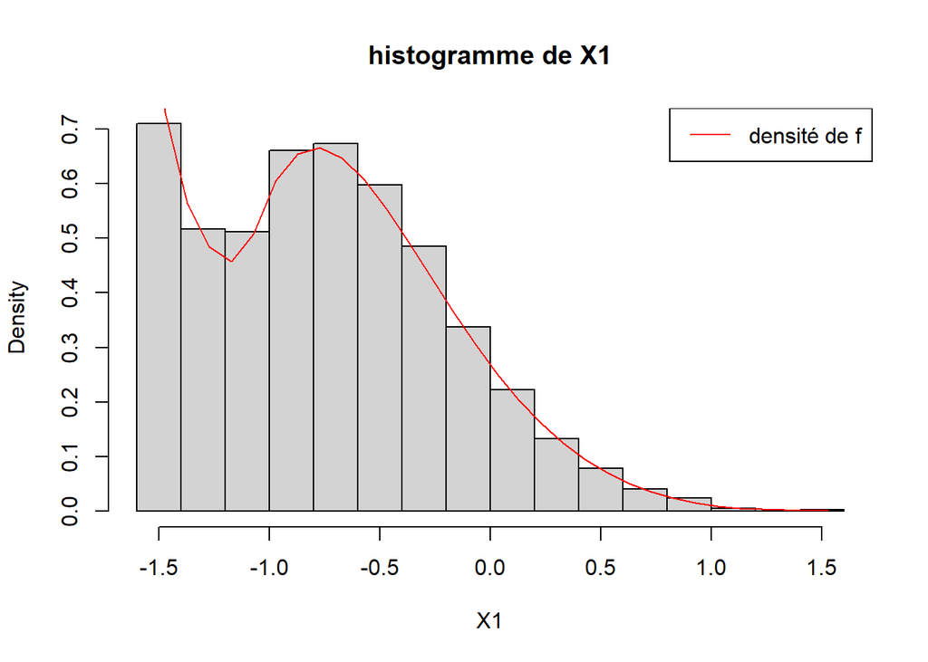

```r
f <- function(x)
{
  M <- (abs(sin((2 / pi) * x ^ 2 - pi / 4)) + 4 * cos(x) ^ 2)
  N <- exp(-2 * x)
  return(M * N * (1 - exp(-2)) + 2 * N * (3 / 4 - 21 / 4 * exp(-2)))
}
fv <- Vectorize(f)
s <- seq(-pi / 2, pi / 2, 0.1)
y <- an * fv(s)
hist(z[1, ],
     freq = FALSE,
     xlab = "X1",
     main = "")
title("histogramme de X1")
lines(s, y, col = 'red')
legend("topright", legend = "densité de f", lty=1:2, col = "red")
```

## méthode 2

**8.** On a $(X_i,Y_i)_{i\geq1}$ iid et intégrable (continue sur un borné) donc d’après la LGN
$$\begin{align}
\hat{w_n}\rightarrow ps~~ E_{f_{X,Y}}(\frac{\psi(x,Y_1)w(X_1)}{\psi(X_1,Y_1)})&=E_{f_{X,Y}}(\frac{f(x,Y_1)w(X_1)}{f(X_1,Y_1)})\\&=\int_{R^2}\frac{f(x,y_1)w(x_1)}{f(x_1,y_1)}f(x_1,y_1)dx_1dy_1\\&=\int_{R^2}f(x,y_1)w(x_1)dx_1dy_1\\&= \int_Rf(x,y_1)\int_Rw(x_1)dx1dy1~~
\text{par funini car une densité est positive} \\
&= \int_Rf(x,y_1)dy_1 ~~~~(\text{w densité donc }\int_Rw(x_1)dx=1 )\\
&=f_x(x)
\end{align}$$
**9**

**10**

```r
w <- function(x)
{
  return(0.2704205 * ((1 - exp(-2)) * (1 / sqrt(0.5 * pi) * exp(-((x + 0.8) /
                                                                    0.5
  )) ^ 2) + ((
    -(21 / 2) * exp(-2) + 3 / 2
  )) * 2 * exp(-2 * (x + 0.8 + pi / 2))))
}
wV <- Vectorize(w)

w_n <- function(x, z, n)
{
  u <- vector(length = n)
  u <- psiV(x, z[2, 1:n]) * wV(z[1, 1:n]) / psiV(z[1, 1:n], z[2, 1:n])
  return(c(mean(u), var(u)))
}

var_w<-w_n(-1,z,n_obs)
p2<-1.96*sqrt(var_w[2]/n_obs)
Iw<-c(var_w[1]-p2,var_w[1]+p2)
```

On trouve $w_n =$ 0.6194852 et $I=$[0.6034826,0.6354878]

# Exo2

**1**

```r
n <- 10000
mu <- c(0.1, 0, 0.1)
sigma <- rbind(c(0.047, 0, 0.0117), c(0, 0.047, 0), c(0.0117, 0, 0.047))

rmvnorm <- function(n, mu, sigma) {
  L <- t(chol(sigma))
  X <- matrix(rnorm(3 * n), nrow = length(mu))

  W = mu + L %*% X
  return(W)
}

set.seed(0)
x <- rmvnorm(n, mu, sigma);
```

**2** On estime $\delta$ par $\overline{\delta}=\frac{1}{n}\sum_{i=1}^nmin(3,\frac{1}{3}\sum_{k=1}^3e^{-X_k^{i}})$ où $(X_1^{i},X_2^{i},X_3^{i})_{i>0}\overset{iid}\sim N(\mu, \Sigma)$

```r
teta_barre <- function(x)
{
  x <- colMeans(exp(-x))
  x[x > 3] <- 3
  return(x)
}

x1 <- teta_barre(x)
teta1 <- mean(x1)
var_teta1 <- var(x1)
erreur_quadra_teta1 <- (1 / n) * var(x1)
```

On trouve $\delta =$ 0.9579442 et l’erreur quadratique moyenne associé est 1.704613210^{-6}.

**3** Comme dans le cours, on utilise le fait que $A(X)=2\mu-X \overset{iid}\sim N(\mu,\Sigma)$. Comme A est est décroissante en chacune des coordonnées de $X$, on a $cov(X,AX)<0$ condition suffisante pour que l’on ai : $var(\hat{\delta})\leq var(\overline{\delta})/2$ avec $\hat{\delta}=\frac{1}{n}\sum_{i=1}^n \frac{min(3,\frac{1}{3}\sum_{k=1}^3e^{-X_k^{i}})+min(3,\frac{1}{3}\sum_{k=1}^3e^{-AX_k^{i}})}{2}$.

```r
teta_chapeau <- function(x) {
  y <- (2 * mu) - x
  y <- colMeans(exp(-y))
  y[y > 3] <- 3
  z <- colMeans(exp(-x))
  z[z > 3] <- 3

  return(rbind(z,y))
}

u<-teta_chapeau(x)
x2 <- colMeans(u)
p<-cov(u[1,],u[2,])/var(u[1,])
R1<-4/(3*(1+p))
teta2 <- mean(x2)
var_teta2 <- var(x2)
erreur_quadra_teta2 <- (1 / n) * var(x2)
```

**4** On utilise le développement limité d’ordre 2 de $e^{-x}$ pour obtenir $h_0$. On prend:
$$h_0(x)=\frac{1}{3}\sum_{k=1}^31-x_k+\frac{x_k^2}{2}=1+\frac{1}{3}\sum_{k=1}^3-x_k+\frac{x_k^2}{2}$$
.

```r
h0 <- function(x) {
  y <- (x ** 2)/2
  z <- colMeans(-x + y)
  return(1 + z)
}

correlation <- cor(h0(x), teta_barre(x))
```

On obtient que $corr(h_0(x),h(x))=$ 0.9997691. On prend ainsi comme estimateur de $\delta$, $\hat{\delta}_n(b)= \frac{1}{n}\sum_{i=1}^n (min(3,\frac{1}{3}\sum_{k=1}^3e^{-X_k^{i}})-b(h_0(X^{i})-E(h_0(X)))$. Calcul de $E(h_0(X))$:
$$\begin{align}
E(h_0(X))&= 1+\frac{1}{3}\sum_{k=1}^3-E(X_k)+\frac{E(X_k^2)}{2}\\
&= 1+\frac{1}{3}\sum_{i=1}^3-E(X_k)+\frac{1}{2}(V(X_k)+E(X_k)^2)\\
&= 1+\frac{1}{3}(-0.2 + \frac{1}{2}(0.047 \times 3 + 2 \times 0.1^2))\\
&= 0.96
\end{align}$$

```r
teta_chapeau_b <- function(x, l, n) {
  y <- h0(x)
  x <- teta_barre(x)

  b <- cov(y[1:l], x[1:l]) / var(y[1:l])

  z <- x[(l + 1):n] - b * (y[(l + 1):n] - 0.96)
  return(z)

}

x3 <- teta_chapeau_b(x, 1000, n)
teta3 <- mean(x3)
var_teta3 <- var(x3)
erreur_quadra_teta3 <- (1 / n) * var(x3)
```

On trouve $\delta =$ 0.9586496 et l’erreur quadratique moyenne associé est 7.969955710^{-10}. On voit que si on diminue le nombre de simulations utilisés pour b, la variance augmente. A l’inverse si b est trop grand, le biais augmente.

# exo3

**1** On propose comme estimateur de $\delta$, $\hat{\delta}=\frac{1}{n}\sum_{j=1}^n\sum_{i=1}^{Y_j}\log(X_i^j+1)$ avec $(Y_j)_{j\geq1} \overset{iid}\sim G(p)$ et $((X_i^j)_{i\leq j})_{j\geq0} \overset{iid}\sim \Gamma(m,\theta)$ Comme l’estimateur est sans biais,l’erreur quadratique est $\frac{1}{n}var(\sum_{i=1}^{Y}\log(X_i+1))$ .

```r
gen_gama <- function(m)
{
  return(sum(log(rgamma(m, 2, 2) + 1)))
}
gen_gamav <- Vectorize(gen_gama)

Monte_classique <- function(n)
{
  m <- rgeom(n, 0.2) + 1 #rang du premier succÃ¨s
  x <- gen_gamav(m)
  EM <- mean(x)
  EQ <- 1 / n * (var(x))
  return(c(EM, EQ))
}
monte_est<-Monte_classique(n_obs)
```

On obtient $\delta =$ 3.2075518et l’erreur quadratique est 8.740090410^{-4}

**2** On prend comme strates $D_k=\{Y=k+1\} ~~~\forall 0\leq k \leq 14$ et $D_{15}=\{Y>14\}$ On utilise l’allocation proportionelle on a donc $\forall 0\leq k \leq 14~~~~ q_k=n*P(Y=k)$. Notre estimateur est donc $\hat{\delta}_2=\sum_{k=1}^{14}P(Y=k)\frac{1}{n_k}\sum_{j=1}^{n_k}\sum_{i=1}^{k}\log(X_i^k+1)$

```r
strat <- function(n)
{
  D <- c(0:13)   # trouver les p_k
  u <- dgeom(D, 0.2)
  ni <- n * u   #trouver les n_k
  u <- c(u, 1 - sum(u)) #p_15
  ni <- round(ni, 0)#n_k doit être un entier
  ni <- c(ni, n - sum(ni))  #n_15

  v <- vector(length = 15) #vecteur des variances des strates
  m2 <- 0 # On calcul la sum au fur et à mesure
  for (i in 1:15)
  {
    p <- gen_gamav(rep(i, ni[i])) #generre n_k gamma avec m=k
    m2 <- m2 + mean(p) * u[i]
    v[i] = var(p) * u[i]
  }
  EQ2 <- 1 / n * sum(v)
  return(c(m2, EQ2))
}
```

L’efficacité relative est $\frac{C\sigma_{MC}}{C_1\sigma_{str}}$. On la calcule ainsi:

```r
library(microbenchmark)
#problème pour n petit car certaines strates sont sans observations dans l'estimateur stratifié
c <-
  microbenchmark(ST <-
                   strat(n_obs), MC <- Monte_classique(n_obs), times = 10)[, 2]
c <- c[2] / c[1]
ER <- c * MC[2] / ST[2]
EQ2<-ST[2]
```

L’erreur quadratique est 4.948762910^{-5} On a alors que pour un même nombre d’observations, $\hat{\delta}_2$ est en moyenne 12.7581088 fois plus efficaces que l’estimateur de monte-carlo classique